# Covid19 EDA for US States

Load the data and uncumulate

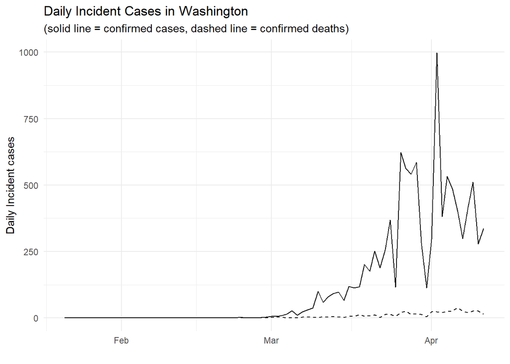

```r
# Load the state data
state_cases <- read.delim('data/covid-19-data/us-states.csv', sep=",", header = TRUE, stringsAsFactors = FALSE) %>%
  mutate(date = ymd(date), cum_cases = cases, cum_deaths = deaths) %>%
  group_by(state) %>%
  mutate(cases = c(cum_cases[1], diff(cum_cases)),
         deaths = c(cum_deaths[1], diff(cum_deaths)))


# Let's visualize for Washington
state_cases %>%
  filter(state == "Washington") %>%
  ggplot(aes(x = date)) +
  geom_line(aes(y = cases)) +
  geom_line(aes(y = deaths), lty = "dashed") +
  labs(x = "", y = "Daily Incident cases" , title = "Daily Incident Cases in Washington",
       subtitle = "(solid line = confirmed cases, dashed line = confirmed deaths)") +
  theme_minimal()
```

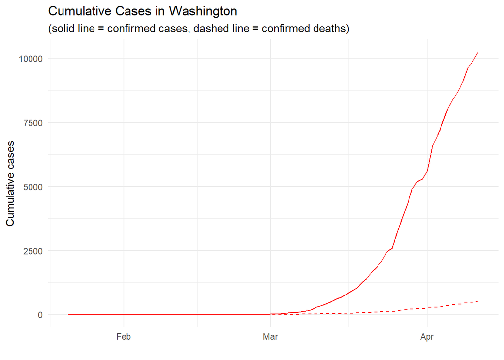

```r
state_cases %>%
  filter(state == "Washington") %>%
  ggplot(aes(x = date)) +
  geom_line(aes(y = cum_cases), color = "red") +
  geom_line(aes(y = cum_deaths), color = "red", lty = "dashed") +
  labs(x = "", y = "Cumulative cases" , title = "Cumulative Cases in Washington",
       subtitle = "(solid line = confirmed cases, dashed line = confirmed deaths)") +
  theme_minimal()
```

## EDA

Let’s take a look at the states hit hardest so far by COVID-19, simply because it’s too much to look at every single state. I’ll set a threshold at 500 total cases per million for defining hotspot states. Any time a new state meets this threshold we’ll know.

```r
# Load the population data by state (from US Census)
state_pop <- read.delim("data/us-population-by-state.csv", sep = ",", header=TRUE, stringsAsFactors = FALSE)
state_cases %>%
  filter(date == today()-1) %>%
  left_join(state_pop, by = "state") %>%
  mutate(fraction = cum_cases/population) %>%
  # set the threshold at 500 cases per million
  filter(fraction > 0.0005) %>%
  pull(state) -> hotspot_states

# Add California even though the cumulative cases < threshold
hotspot_states <- c("California", hotspot_states)

# Compare to old hotspot states saved as an RDS object
old_hotspot_states <- readRDS("data/hotspot_states.rds")
cat(hotspot_states[!(hotspot_states %in% old_hotspot_states)], "just became new hotspots!")
```

```
##  just became new hotspots!
```

```r
# Let's save this for future use so we can compare whether new states have passed this threshold
saveRDS(hotspot_states, "data/hotspot_states.rds")
rm(old_hotspot_states)
```

Visualize cumulative cases and cumulative deaths for states that meet the threshold plus California.

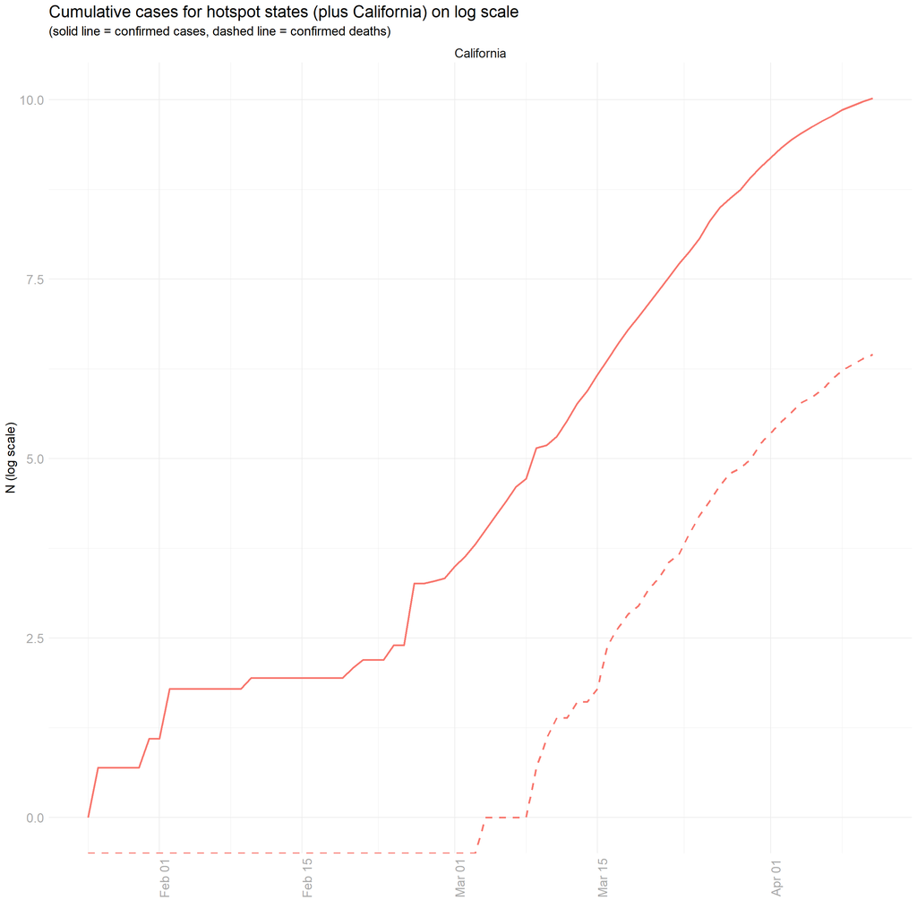

```r
state_cases %>% filter(state %in% hotspot_states) %>%
  ggplot(aes(x=date, color=state)) +
  geom_line(aes(y=log(cum_cases)), size = 1) +
  geom_line(aes(y=log(cum_deaths)), lty="dashed", size = 1) +
  labs(x = "", y = "N (log scale)", title = "Cumulative cases for hotspot states (plus California) on log scale",
       subtitle = "(solid line = confirmed cases, dashed line = confirmed deaths)") +
  facet_wrap(~state) +
  my_theme +
  theme(axis.text.x = element_text(angle = 90, hjust = 0.5, size = 14),
        axis.text.y = element_text(size = 14))
```

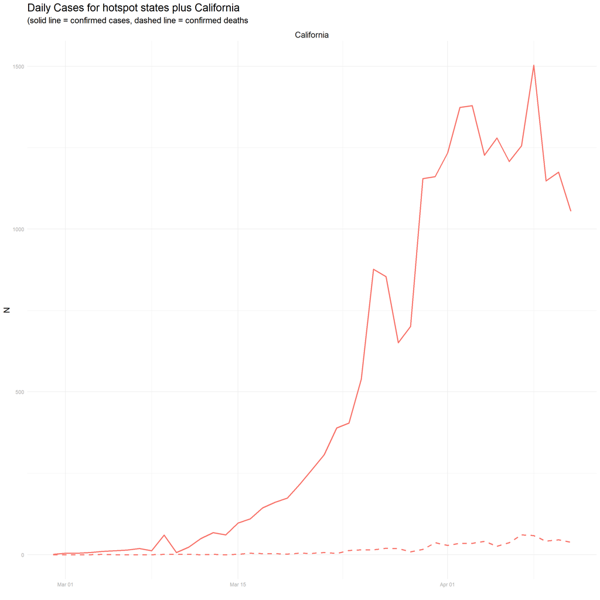

```r
state_cases %>% filter(date > ymd("2020-02-28"), state %in% hotspot_states) %>%
  ggplot(aes(x=date, color=state)) +
  geom_line(aes(y=cases), size = 1) +
  geom_line(aes(y=deaths), lty="dashed", size = 1) +
  labs(x = "", y = "N",
       title = "Daily Cases for hotspot states plus California",
       subtitle = "(solid line = confirmed cases, dashed line = confirmed deaths") +
  facet_wrap(~state, scales = "free_y") +
  my_theme
```

Let’s explore a few of these states in detail and see if the trends we see are real and if we can make some projections about where they are headed. I obviously can’t talk about every single state here, but will soon create a Shiny app or something of the sort for each state and county.

## Washington

Seattle, and by proxy Washington, was one of the first hotbeds of COVID-19 in the US. It’s been on lockdown for a while and is seemingly in the decay phase now. Washington should serve as a good benchmark for our model and projections.

### Modeling the incidence using log-linear models

log y = r t + b,

where y is the incidence, r is the growth rate, t is the duration, and b is the intercept. You obviously need to fit two different models — one for the growth phase and the other for decay phase (if present). The package incidence from RECON is a great tool for doing this, though it’s easy to do using base R.

First, we’ll create a vector of dates, one for each case in Washington, using the uncount function from the tidyr package and then create an incidence object. We will then fit two log-linear models, one each for growth and decay phases.

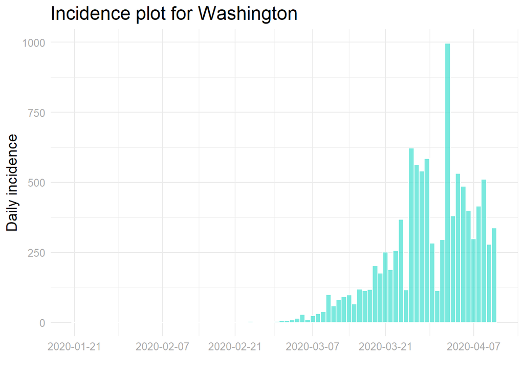

```r
# Format data for use by the incidence package
wa_inc_cases <- state_cases %>%
  filter(state == "Washington") %>%
  ungroup() %>%
  select(date, cases) %>%
  uncount(cases)

# Create an incidence object and find the peak
i.wa <- incidence(wa_inc_cases$date)

plot(i.wa, color = 'turquoise', border = 'white') +
  theme_minimal() +
  labs(title = "Incidence plot for Washington") +
  theme(axis.title = element_text(size = 14),
        axis.text = element_text(size = 10, color = 'darkgrey'),
        plot.title = element_text(size = 18))
```

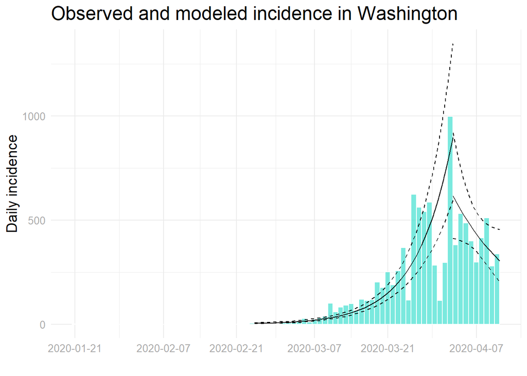

```r
i.wa.peak <- incidence::find_peak(i.wa)
# Setting the start date helps with a better fit -- almost forced to do this due to a lack of robust data in the uS
i.wa.fit <- incidence::fit(subset(i.wa, from = ymd('2020-02-07')), split = i.wa.peak)
plot(i.wa, color="turquoise", border="white") %>%
  add_incidence_fit(i.wa.fit) +
  theme_minimal() +
  labs(title = "Observed and modeled incidence in Washington") +
  theme(axis.title = element_text(size = 14),
        axis.text = element_text(size = 10, color = 'darkgrey'),
        plot.title = element_text(size = 18))
```

```r
# Look at estimated doubling and halving times
i.wa.fit
```

```
## <list of incidence_fit objects>
##
## attr(x, 'locations'): list of vectors with the locations of each incidence_fit object
##
## 'before'
## 'after'
##
## $model: regression of log-incidence over time
##
## $info: list containing the following items:
##   $r (daily growth rate):
##      before       after
##  0.14281672 -0.07825851
##
##   $r.conf (confidence interval):
##             2.5 %       97.5 %
## before  0.1228825  0.162750919
## after  -0.1530112 -0.003505776
##
##   $doubling (doubling time in days):
##   before
## 4.853404
##
##   $doubling.conf (confidence interval):
##           2.5 %  97.5 %
## before 4.258945 5.64073
##
##   $halving (halving time in days):
##    after
## 8.857147
##
##   $halving.conf (confidence interval):
##          2.5 %   97.5 %
## after 4.530041 197.7157
##
##   $pred: data.frame of incidence predictions (46 rows, 6 columns)
```

### Estimating the reproduction rate

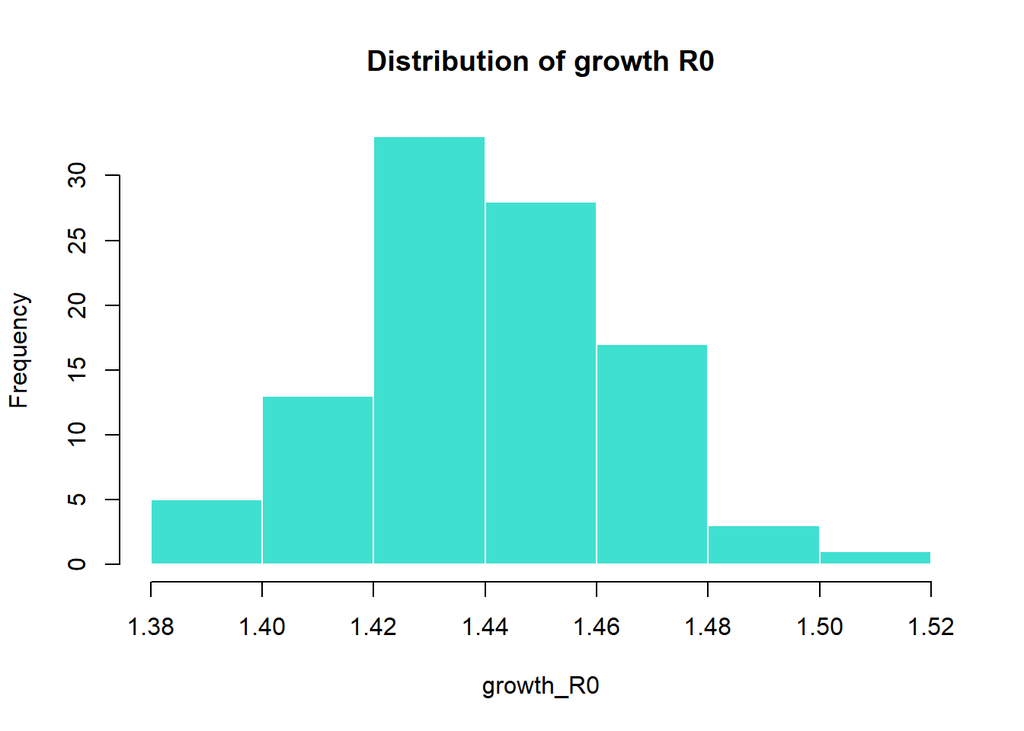

```r
# Set params from Du et al. (2020)
mu <- 3.96
sigma <- 4.75
param <- epitrix::gamma_mucv2shapescale(mu, sigma/mu)

w <- distcrete("gamma", interval = 1, shape = param$shape, scale = param$scale, w = 0)
growth_R0 <- epitrix::lm2R0_sample(i.wa.fit$before$model, w)
hist(growth_R0, col = "turquoise", border = "white", main = "Distribution of growth R0")
```

Interestingly, the median growth $R_{0}$ estimated here is significantly lower than what’s been published. I suspect that this is due to a limited number of testing available in the US, thereby suppressing the actual number of cases out there. The $R_{0}$ is not really important for our purposes though. We are interested in a general trend to see if the effective reproduction number, $R_{e}$, has gone down indicating whether the number of new infections are also trending down.

### Estimating the effective reproduction number

`EpiEstim` package from RECON allows several different ways to estimate $R_{e}$, all of which are dependent on the SI distribution. We’ll use the Du et al. (2020) estimates again to specify the SI and then generate $R_{e}$.

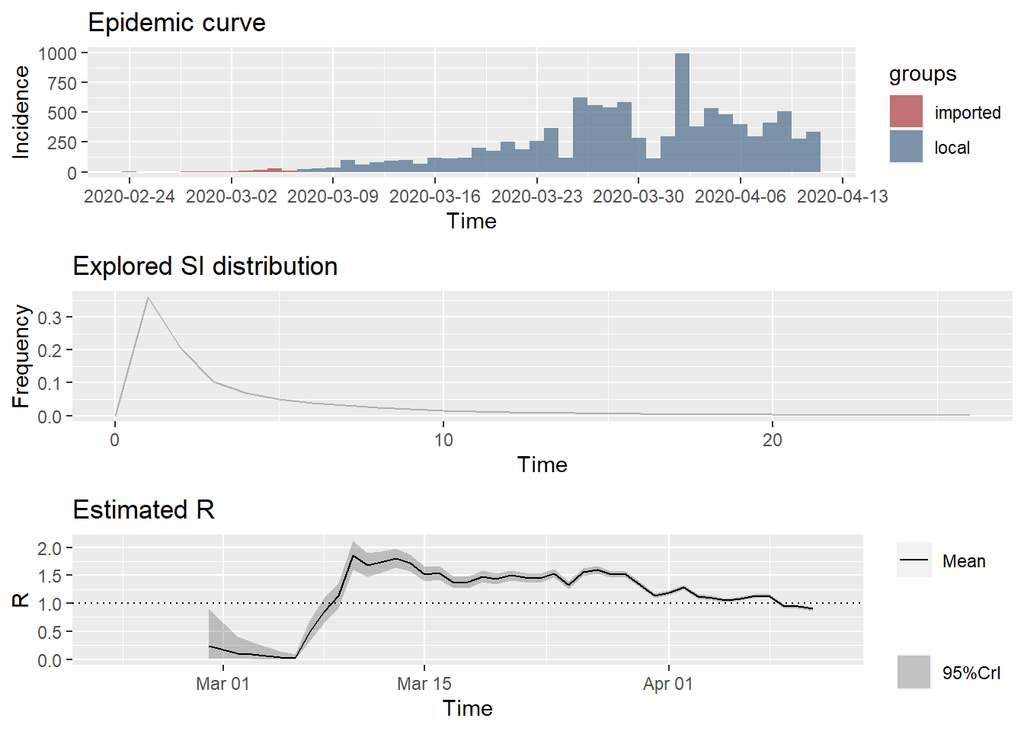

```r
wa_cases <- state_cases %>%
  filter(state == "Washington") %>%
  ungroup() %>%
  mutate(imported = ifelse(date < ymd("2020-03-07"), cases, 0),
         local = ifelse(date < ymd("2020-03-07"), 0, cases)) %>%
  select(date, local, imported) %>%
  rename(dates=date)

wa_res <- EpiEstim::estimate_R(
  wa_cases[wa_cases$dates > ymd('2020-02-21'),], method = "parametric_si", config = make_config(
    list(mean_si = mu, std_si = sigma)))
plot_Ri(wa_res)
```

The key thing to notice here is that the $R_{e}$ is trending down and is close to 1, which is an all important threshold indicating that one infected person infects less than one person essentially signaling the death of the epidemic. You could be snarky and say, “duh! you could have predicted that from the incidence plot,” and I would retort, “yes, but you would have found that out on April 3rd at best on the day after the peak assuming it didn’t spike back up, but the effective reproductive number has been on a downtrend since the second week of March! So, there…”

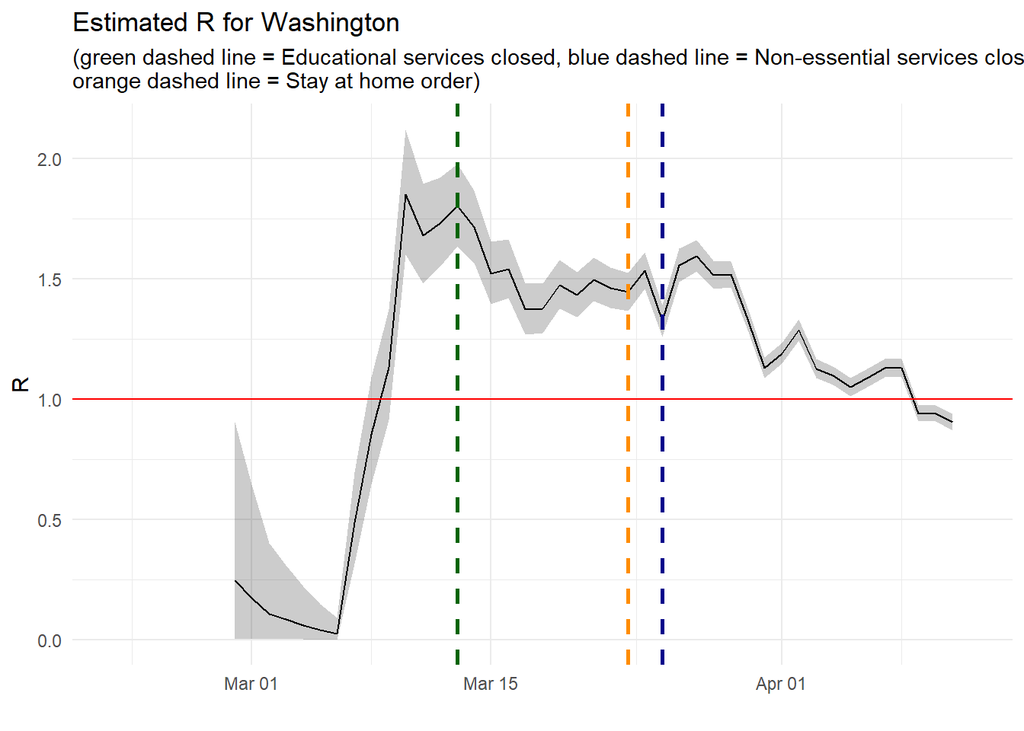

```r
plot(wa_res, "R") +
  geom_hline(yintercept = 1, lty = "solid", color = "red") +
  geom_vline(xintercept = ymd('2020-03-13'), lty = 'dashed', color = 'darkgreen', size = 1) +
  geom_vline(xintercept = ymd('2020-03-25'), lty = 'dashed', color = 'darkblue', size = 1) +
  geom_vline(xintercept = ymd('2020-03-23'), lty = 'dashed', color = 'darkorange', size = 1) +
  labs(x = "", title = "Estimated R for Washington",
       subtitle = "(green dashed line = Educational services closed, blue dashed line = Non-essential services closed, \norange dashed line = Stay at home order)") +
  theme_minimal() +
  theme(legend.position = 'none')
```

We can do the same for other states. Let’s quickly look at Pennsylvania and Washington, DC because both reported a huge spike in numbers yesterday.

## Pennsylvnia

Below is the incidence plot for Pennsylvania. Note that I only chose to fit it to the first peak of April 3rd because I think the testing was backlogged and the actual confirmed cases are lagging. This is part based on data (confirmed death cases) and reporting and part qualititative. Confirmed deaths is probably a better proxy as pointed out by Tomas Pueyo and used by IHME in their projections (I’ll be incorporating those into the model).

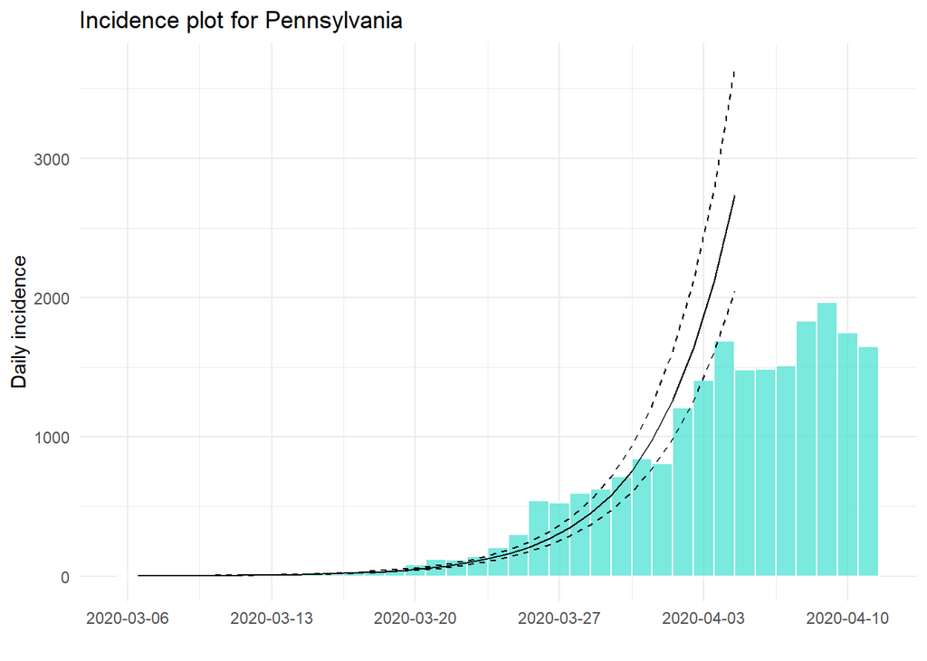

```r
pa_inc_cases <- state_cases %>%
  filter(state == "Pennsylvania") %>%
  ungroup() %>%
  select(date, cases) %>%
  uncount(cases)

# Create an incidence object and find the peak
i.pa <- incidence(pa_inc_cases$date)
i.pa.peak <- incidence::find_peak(i.pa)
i.pa.early.fit <- incidence::fit(subset(i.pa, to = ymd('2020-04-04')))
plot(i.pa, color="turquoise", border="white") %>%
  add_incidence_fit(i.pa.early.fit) +
  labs(title = "Incidence plot for Pennsylvania") +
  theme_minimal()
```

```r
i.pa.early.fit
```

```
## <incidence_fit object>
##
## $model: regression of log-incidence over time
##
## $info: list containing the following items:
##   $r (daily growth rate):
## [1] 0.257797
##
##   $r.conf (confidence interval):
##          2.5 %    97.5 %
## [1,] 0.2407541 0.2748399
##
##   $doubling (doubling time in days):
## [1] 2.688733
##
##   $doubling.conf (confidence interval):
##         2.5 %   97.5 %
## [1,] 2.522004 2.879067
##
##   $pred: data.frame of incidence predictions (30 rows, 5 columns)
```

```r
pa_cases <- state_cases %>%
  filter(state == "Pennsylvania") %>%
  ungroup() %>%
  mutate(imported = 0,
         local =  cases) %>%
  select(date, local, imported) %>%
  rename(dates=date)

pa_res <- EpiEstim::estimate_R(
  pa_cases, method = "parametric_si", config = make_config(
    list(mean_si = mu, std_si = sigma)))
```

```
## Default config will estimate R on weekly sliding windows.
##     To change this change the t_start and t_end arguments.
```

```
## The number of colors (8) did not match the number of groups (2).
## Using `col_pal` instead.
```

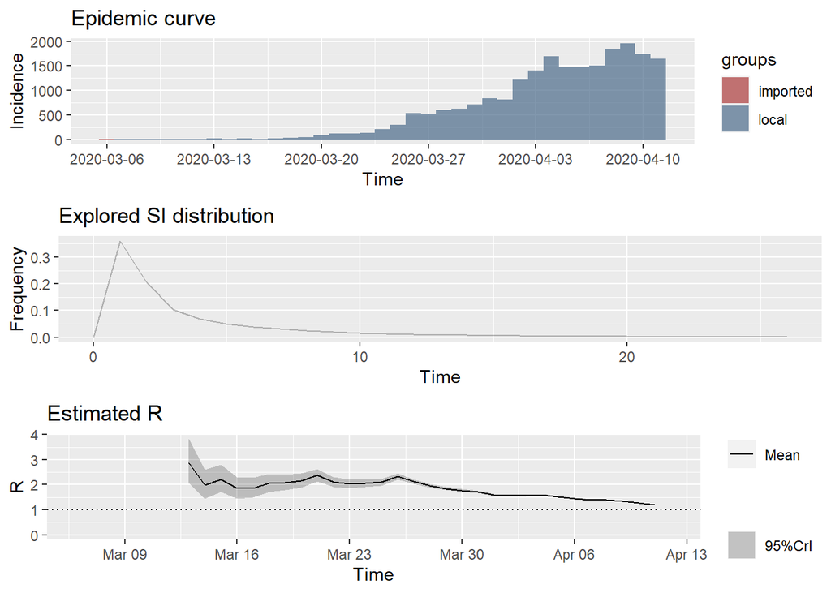

```r
plot_Ri(pa_res)
```

Despite the latest uptick in incident cases, the effective reproductive number has been on a solid downward trend. Pennsylvania still has a lot of work to do though before it’s below 1.

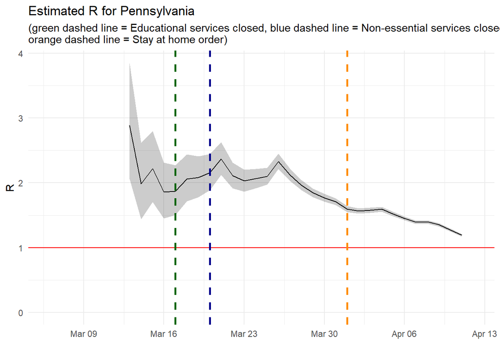

```r
plot(pa_res, "R") +
  #scale_y_continuous(trans = "log2") +
  geom_hline(yintercept = 1, lty = "solid", color = "red") +
  geom_vline(xintercept = ymd('2020-03-17'), lty = 'dashed', color = 'darkgreen', size = 1) +
  geom_vline(xintercept = ymd('2020-03-20'), lty = 'dashed', color = 'darkblue', size = 1) +
  geom_vline(xintercept = ymd('2020-04-01'), lty = 'dashed', color = 'darkorange', size = 1) +
  labs(x = "", title = "Estimated R for Pennsylvania",
       subtitle = "(green dashed line = Educational services closed, blue dashed line = Non-essential services closed, \norange dashed line = Stay at home order)") +
  theme_minimal() +
  theme(legend.position = 'none')
```

## Washington, DC

Below are the same two charts for Washington, DC, which are fairly inconclusive, pointing to the limitation of using effective reproduction number to make assessments, especially given the amount of uncertainties in the US with lack of testing.

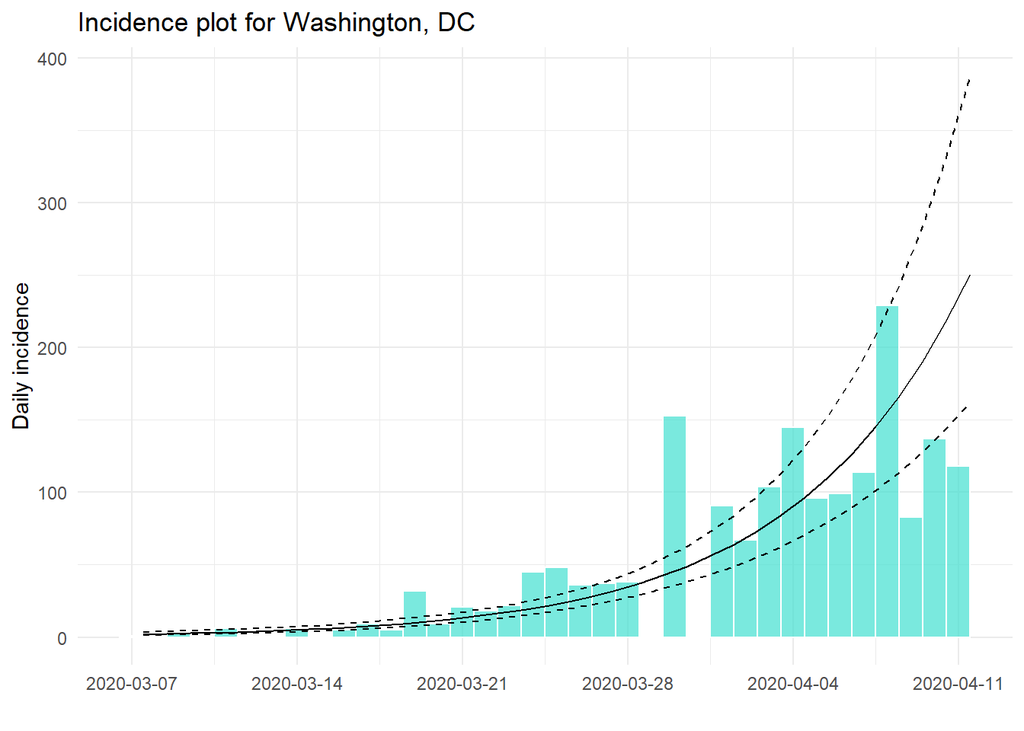

```r
dc_inc_cases <- state_cases %>%
  filter(state == "District of Columbia") %>%
  ungroup() %>%
  select(date, cases) %>%
  uncount(cases)

# Create an incidence object and find the peak
i.dc <- incidence(dc_inc_cases$date)
i.dc.peak <- incidence::find_peak(i.dc)
i.dc.early.fit <- incidence::fit(subset(i.dc))
plot(i.dc, color="turquoise", border="white") %>%
  add_incidence_fit(i.dc.early.fit) +
  labs(title = "Incidence plot for Washington, DC") +
  theme_minimal()
```

```r
i.dc.early.fit
```

```
## <incidence_fit object>
##
## $model: regression of log-incidence over time
##
## $info: list containing the following items:
##   $r (daily growth rate):
## [1] 0.13648
##
##   $r.conf (confidence interval):
##          2.5 %    97.5 %
## [1,] 0.1133625 0.1595976
##
##   $doubling (doubling time in days):
## [1] 5.078745
##
##   $doubling.conf (confidence interval):
##         2.5 %   97.5 %
## [1,] 4.343093 6.114433
##
##   $pred: data.frame of incidence predictions (30 rows, 5 columns)
```

```r
dc_cases <- state_cases %>%
  filter(state == "District of Columbia") %>%
  ungroup() %>%
  mutate(imported = 0,
         local =  cases) %>%
  select(date, local, imported) %>%
  rename(dates=date)

dc_res <- EpiEstim::estimate_R(
  dc_cases, method = "parametric_si", config = make_config(
    list(mean_si = mu, std_si = sigma)))
```

```
## Default config will estimate R on weekly sliding windows.
##     To change this change the t_start and t_end arguments.
```

```
## The number of colors (8) did not match the number of groups (2).
## Using `col_pal` instead.
```

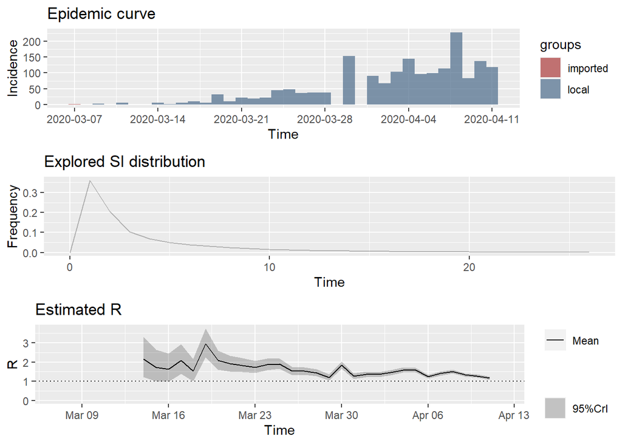

```r
plot_Ri(dc_res)
```

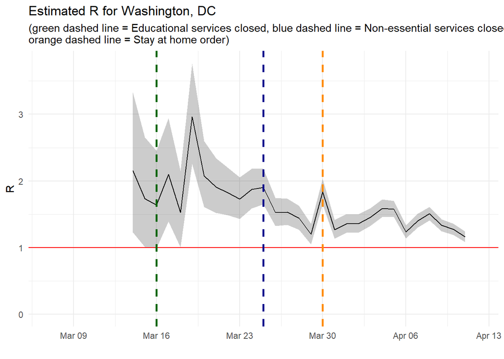

```r
plot(dc_res, "R") +
  #scale_y_continuous(trans = "log2") +
  geom_hline(yintercept = 1, lty = "solid", color = "red") +
  geom_vline(xintercept = ymd('2020-03-16'), lty = 'dashed', color = 'darkgreen', size = 1) +
  geom_vline(xintercept = ymd('2020-03-25'), lty = 'dashed', color = 'darkblue', size = 1) +
  geom_vline(xintercept = ymd('2020-03-30'), lty = 'dashed', color = 'darkorange', size = 1) +
  labs(x = "", title = "Estimated R for Washington, DC",
       subtitle = "(green dashed line = Educational services closed, blue dashed line = Non-essential services closed, \norange dashed line = Stay at home order)") +
  theme_minimal() +
  theme(legend.position = 'none')
```

Estimate the force of infection using the `earlyR` package

```r
dc_simple_R <- get_R(i.dc, si_mean = mu, si_sd = sigma, max_R = 7)
dc_simple_R
```

```
##
## /// Early estimate of reproduction number (R) //
##  // class: earlyR, list
##
##  // Maximum-Likelihood estimate of R ($R_ml):
## [1] 1.373373
##
##
##  // $lambda:
##   0.2087998 0.1578114 0.748937 0.5700994 1.697466 1.298742...
##
##  // $dates:
## [1] "2020-03-08" "2020-03-09" "2020-03-10" "2020-03-11" "2020-03-12"
## [6] "2020-03-13"
## ...
##
##  // $si (serial interval):
## A discrete distribution
##   name: gamma
##   parameters:
##     shape: 0.695029362880886
##     scale: 5.69760101010101
```

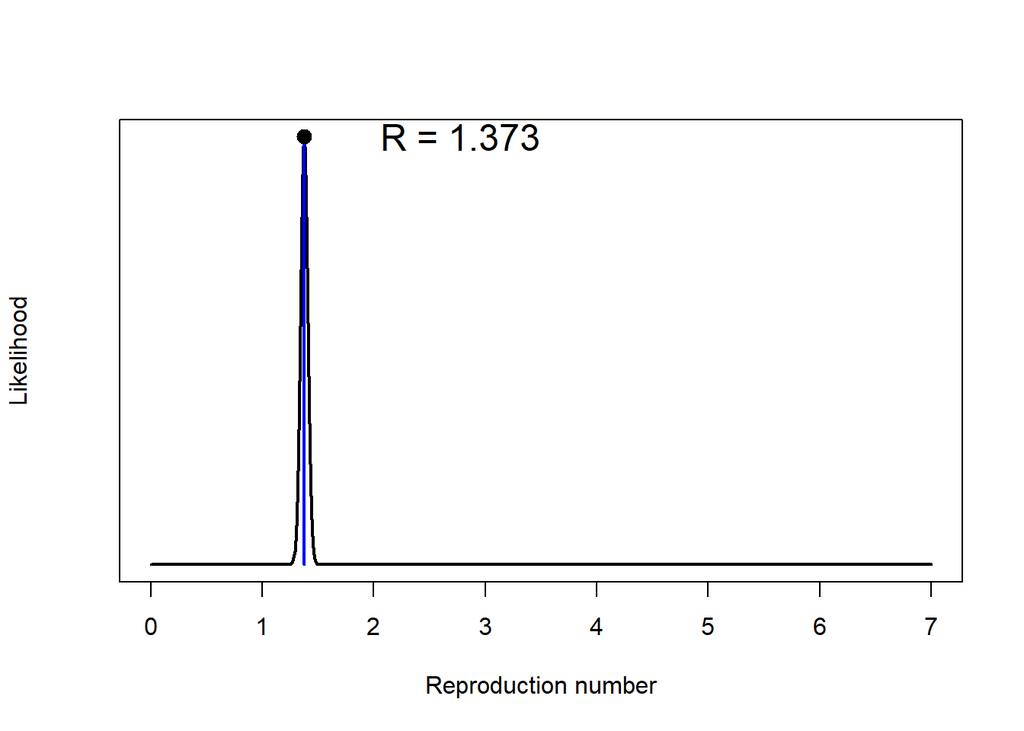

```r
plot(dc_simple_R)
```

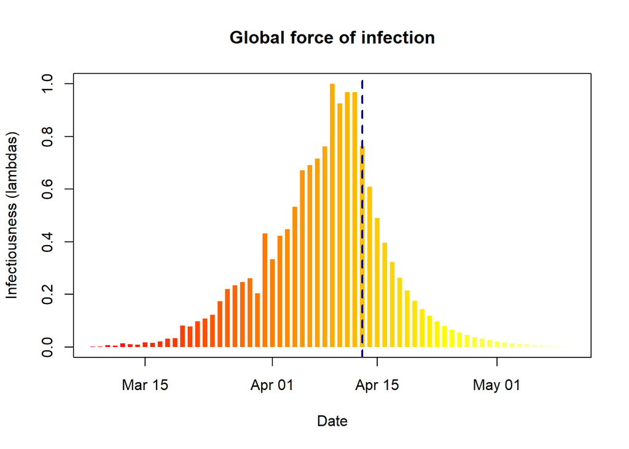

```r
plot(dc_simple_R, 'lambdas')
abline(v = today(), col = 'darkblue', lty = 'dashed', lwd = 2)
```

The effective reproduction number has been trending down and the lambda has also gone down since yesterday, but $R_{0}$ has been volatile and there was the latest uptick, so this one is unclear and hard to make a judgment on. DC had better clamp down.

Some others that are not in the post, but analyzed below

## Virginia

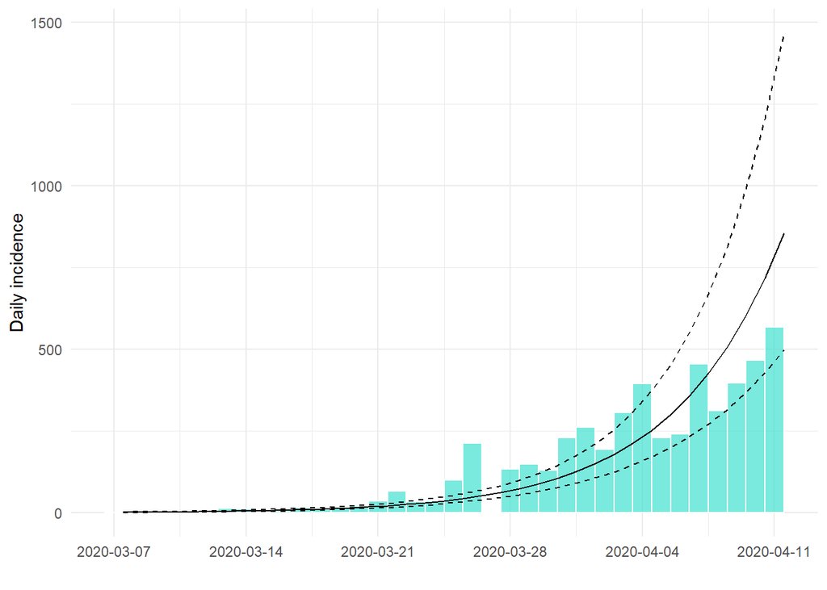

```r
# Format data for use by the incidence package
va_inc_cases <- state_cases %>%
  filter(state == "Virginia") %>%
  ungroup() %>%
  select(date, cases) %>%
  uncount(cases)

# Create an incidence object and find the peak
i.va <- incidence(va_inc_cases$date)
i.va.peak <- incidence::find_peak(i.va)
i.va.fit <- incidence::fit(subset(i.va))
plot(i.va, color="turquoise", border="white") %>%
  add_incidence_fit(i.va.fit) +
  theme_minimal()
```

```r
# Look at estimated doubling time
i.va.fit
```

```
## <incidence_fit object>
##
## $model: regression of log-incidence over time
##
## $info: list containing the following items:
##   $r (daily growth rate):
## [1] 0.1740696
##
##   $r.conf (confidence interval):
##          2.5 %   97.5 %
## [1,] 0.1475651 0.200574
##
##   $doubling (doubling time in days):
## [1] 3.982013
##
##   $doubling.conf (confidence interval):
##         2.5 %  97.5 %
## [1,] 3.455817 4.69723
##
##   $pred: data.frame of incidence predictions (36 rows, 5 columns)
```

Estimate the reproduction number

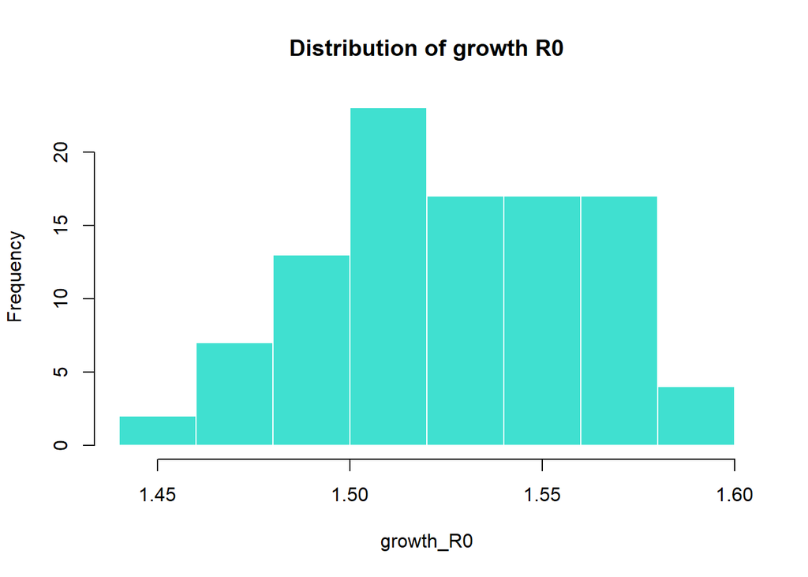

```r
w <- distcrete("gamma", interval = 1, shape = param$shape, scale = param$scale, w = 0)
growth_R0 <- epitrix::lm2R0_sample(i.va.fit$model, w)
hist(growth_R0, col = "turquoise", border = "white", main = "Distribution of growth R0")
```

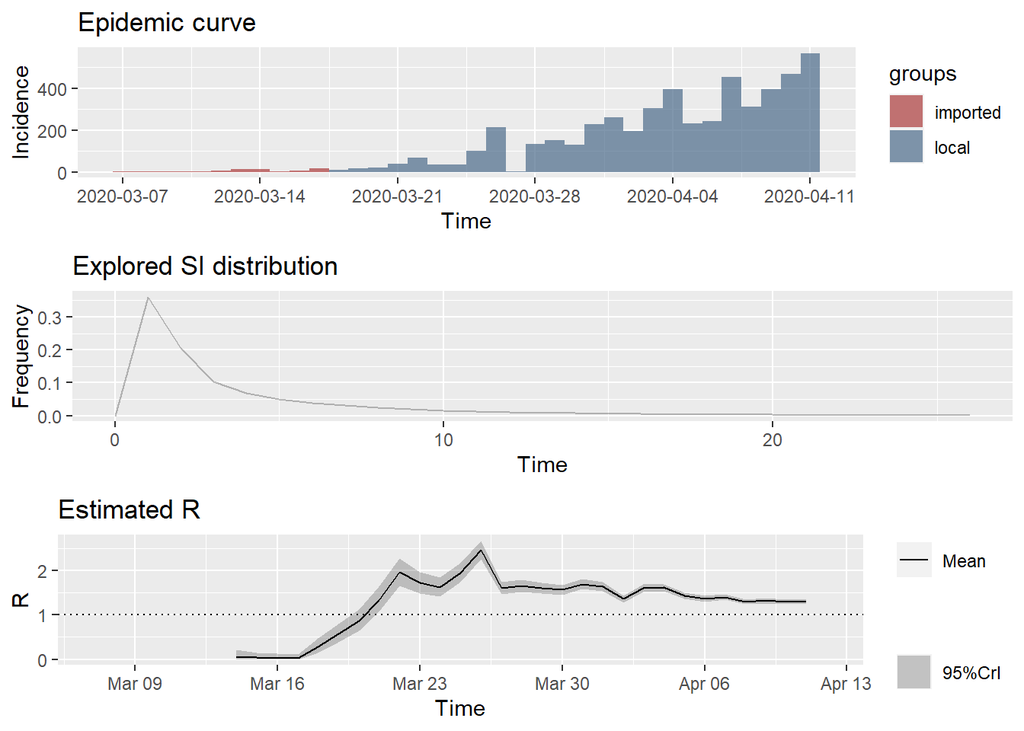

```r
va_cases <- state_cases %>%
  filter(state == "Virginia") %>%
  ungroup() %>%
  mutate(imported = ifelse(date < ymd("2020-03-18"), cases, 0),
         local = ifelse(date < ymd("2020-03-18"), 0, cases)) %>%
  select(date, local, imported) %>%
  rename(dates=date)

va_res <- EpiEstim::estimate_R(
  va_cases, method = "parametric_si", config = make_config(
    list(mean_si = mu, std_si = sigma)))
plot_Ri(va_res)
```

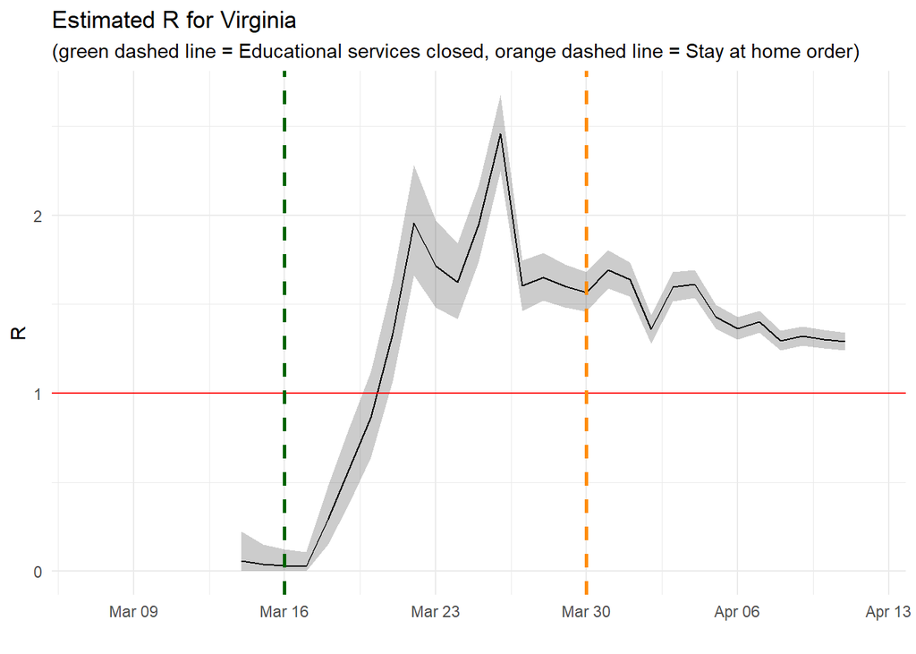

```r
plot(va_res, "R") +
  #scale_y_continuous(trans = "log2") +
  geom_hline(yintercept = 1, lty = "solid", color = "red") +
  geom_vline(xintercept = ymd('2020-03-16'), lty = 'dashed', color = 'darkgreen', size = 1) +
  geom_vline(xintercept = ymd('2020-03-30'), lty = 'dashed', color = 'darkorange', size = 1) +
  labs(x = "", title = "Estimated R for Virginia",
       subtitle = "(green dashed line = Educational services closed, orange dashed line = Stay at home order)") +
  theme_minimal() +
  theme(legend.position = 'none')
```

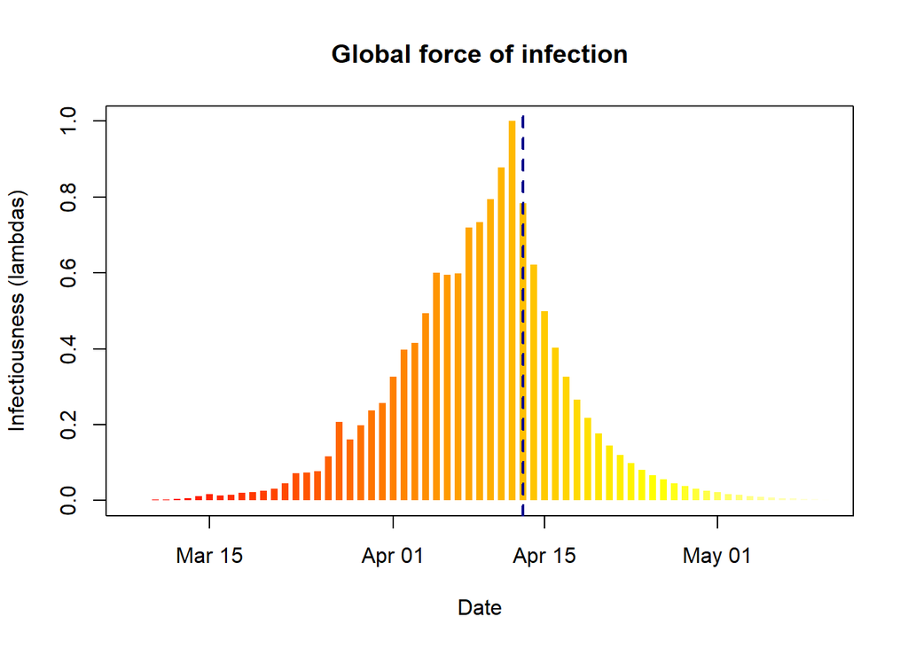

```r
va_simple_R <- get_R(i.va, si_mean = mu, si_sd = sigma)
plot(va_simple_R, 'lambdas')
abline(v = today(), col = 'darkblue', lty = 'dashed', lwd = 2)
```

## New York

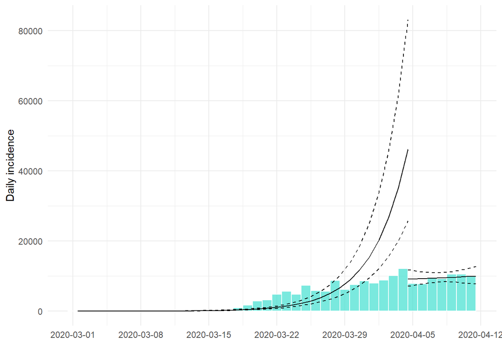

```r
# Format data for use by the incidence package
ny_inc_cases <- state_cases %>%
  filter(state == "New York") %>%
  ungroup() %>%
  select(date, cases) %>%
  uncount(cases)

# Create an incidence object and find the peak
i.ny <- incidence(ny_inc_cases$date)
i.ny.peak <- incidence::find_peak(i.ny)
i.ny.fit <- incidence::fit(i.ny, split = i.ny.peak)
plot(i.ny, color="turquoise", border="white") %>%
  add_incidence_fit(i.ny.fit) +
  theme_minimal()
```

```r
# Look at estimated doubling time
i.ny.fit
```

```
## <list of incidence_fit objects>
##
## attr(x, 'locations'): list of vectors with the locations of each incidence_fit object
##
## 'before'
## 'after'
##
## $model: regression of log-incidence over time
##
## $info: list containing the following items:
##   $r (daily growth rate):
##     before      after
## 0.27498006 0.01143205
##
##   $r.conf (confidence interval):
##              2.5 %     97.5 %
## before  0.24454015 0.30541996
## after  -0.04837654 0.07124065
##
##   $doubling (doubling time in days):
##    before     after
##  2.520718 60.631915
##
##   $doubling.conf (confidence interval):
##           2.5 %     97.5 %
## before 2.269489   2.834492
## after  9.729659 -14.328167
##
##   $pred: data.frame of incidence predictions (42 rows, 6 columns)
```

## Estimate the reproduction number

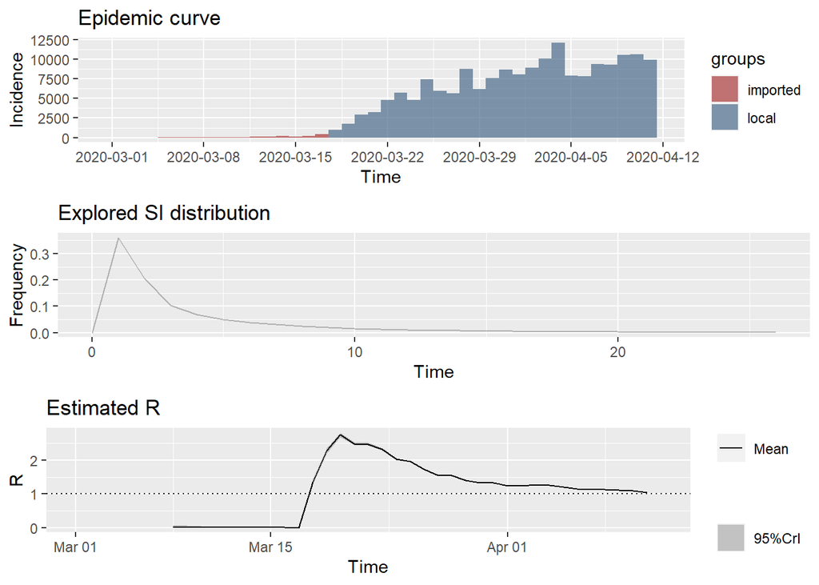

```r
ny_cases <- state_cases %>%
  filter(state == "New York") %>%
  ungroup() %>%
  mutate(imported = ifelse(date < ymd("2020-03-18"), cases, 0),
         local = ifelse(date < ymd("2020-03-18"), 0, cases)) %>%
  select(date, local, imported) %>%
  rename(dates=date)

ny_res <- EpiEstim::estimate_R(
  ny_cases, method = "parametric_si", config = make_config(
    list(mean_si = mu, std_si = sigma)))
plot_Ri(ny_res)
```

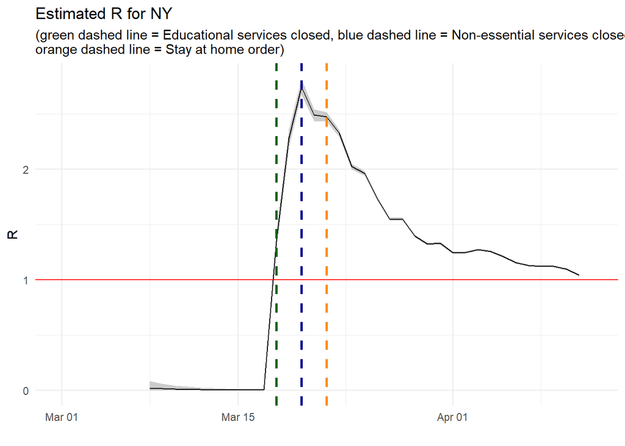

```r
plot(ny_res, "R") +
  #scale_y_continuous(trans = "log2") +
  geom_hline(yintercept = 1, lty = "solid", color = "red") +
  geom_vline(xintercept = ymd('2020-03-18'), lty = 'dashed', color = 'darkgreen', size = 1) +
  geom_vline(xintercept = ymd('2020-03-20'), lty = 'dashed', color = 'darkblue', size = 1) +
  geom_vline(xintercept = ymd('2020-03-22'), lty = 'dashed', color = 'darkorange', size = 1) +
  labs(x = "", title = "Estimated R for NY",
       subtitle = "(green dashed line = Educational services closed, blue dashed line = Non-essential services closed, \norange dashed line = Stay at home order)") +
  theme_minimal() +
  theme(legend.position = 'none')
```

## California

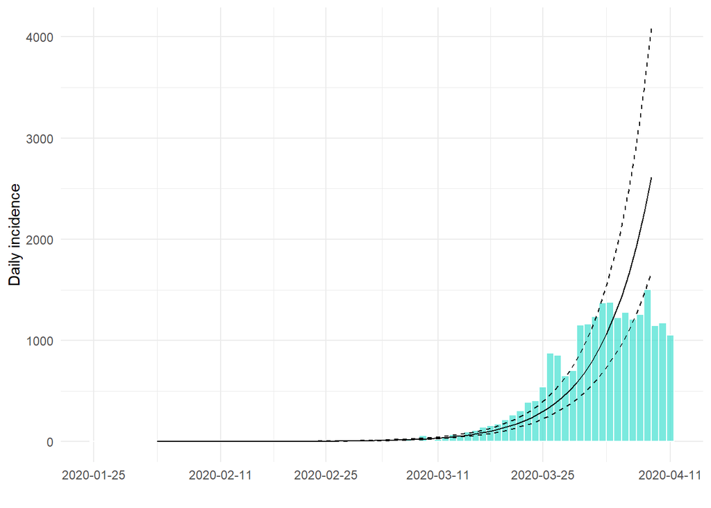

```r
ca_inc_cases <- state_cases %>%
  filter(state == "California") %>%
  ungroup() %>%
  select(date, cases) %>%
  uncount(cases)

# Create an incidence object and find the peak
i.ca <- incidence(ca_inc_cases$date)
i.ca.peak <- incidence::find_peak(i.ca)
i.ca.early.fit <- incidence::fit(subset(i.ca, from = ymd('2020-02-01'), to = i.ca.peak))
plot(i.ca, color="turquoise", border="white") %>%
  add_incidence_fit(i.ca.early.fit) +
  theme_minimal()
```

```r
i.ca.early.fit
```

```
## <incidence_fit object>
##
## $model: regression of log-incidence over time
##
## $info: list containing the following items:
##   $r (daily growth rate):
## [1] 0.1496652
##
##   $r.conf (confidence interval):
##          2.5 %    97.5 %
## [1,] 0.1339362 0.1653942
##
##   $doubling (doubling time in days):
## [1] 4.631318
##
##   $doubling.conf (confidence interval):
##        2.5 %   97.5 %
## [1,] 4.19088 5.175205
##
##   $pred: data.frame of incidence predictions (47 rows, 5 columns)
```

```r
ca_cases <- state_cases %>%
  filter(state == "California") %>%
  ungroup() %>%
  mutate(imported = ifelse(date < ymd("2020-03-10"), cases, 0),
         local = ifelse(date < ymd("2020-03-10"), 0, cases)) %>%
  select(date, local, imported) %>%
  rename(dates=date)

ca_res <- EpiEstim::estimate_R(
  ca_cases, method = "parametric_si", config = make_config(
    list(mean_si = mu, std_si = sigma)))
```

```
## Default config will estimate R on weekly sliding windows.
##     To change this change the t_start and t_end arguments.
```

```
## The number of colors (8) did not match the number of groups (2).
## Using `col_pal` instead.
```

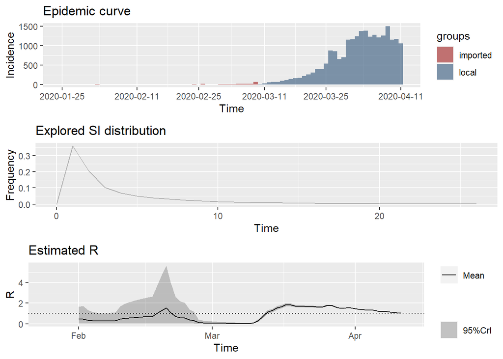

```r
plot_Ri(ca_res)
```

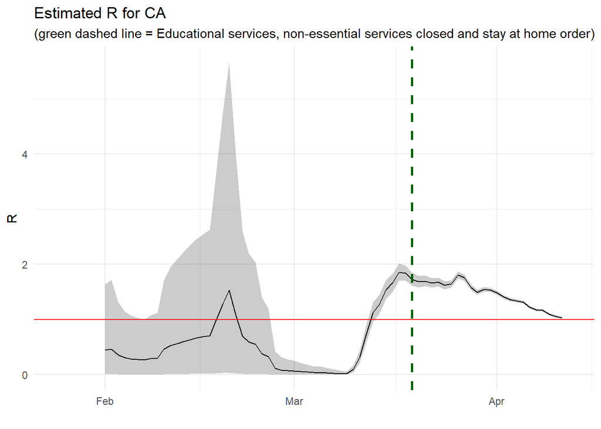

```r
plot(ca_res, "R") +
  #scale_y_continuous(trans = "log2") +
  geom_hline(yintercept = 1, lty = "solid", color = "red") +
  geom_vline(xintercept = ymd('2020-03-19'), lty = 'dashed', color = 'darkgreen', size = 1) +
  labs(x = "", title = "Estimated R for CA",
       subtitle = "(green dashed line = Educational services, non-essential services closed and stay at home order)") +
  theme_minimal() +
  theme(legend.position = 'none')
```

## Massachusetts

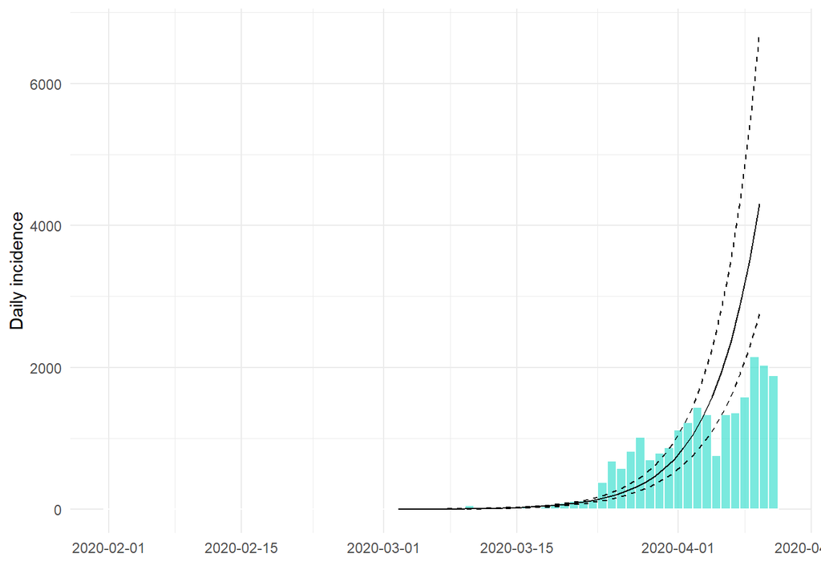

```r
ma_inc_cases <- state_cases %>%
  filter(state == "Massachusetts") %>%
  ungroup() %>%
  select(date, cases) %>%
  uncount(cases)

# Create an incidence object and find the peak
i.ma <- incidence(ma_inc_cases$date)
i.ma.peak <- incidence::find_peak(i.ma)
i.ma.early.fit <- incidence::fit(subset(i.ma, from = ymd('2020-02-14'), to = i.ma.peak))
plot(i.ma, color="turquoise", border="white") %>%
  add_incidence_fit(i.ma.early.fit) +
  theme_minimal()
```

```r
i.ma.early.fit
```

```
## <incidence_fit object>
##
## $model: regression of log-incidence over time
##
## $info: list containing the following items:
##   $r (daily growth rate):
## [1] 0.2010989
##
##   $r.conf (confidence interval):
##          2.5 %    97.5 %
## [1,] 0.1798666 0.2223312
##
##   $doubling (doubling time in days):
## [1] 3.446798
##
##   $doubling.conf (confidence interval):
##         2.5 %   97.5 %
## [1,] 3.117633 3.853674
##
##   $pred: data.frame of incidence predictions (37 rows, 5 columns)
```

```r
ma_cases <- state_cases %>%
  filter(state == "Massachusetts", date>ymd('2020-03-07')) %>%
  ungroup() %>%
  mutate(imported = 0, local = cases) %>%
  select(date, local, imported) %>%
  rename(dates=date)

ma_res <- EpiEstim::estimate_R(
  ma_cases, method = "parametric_si",
  config = make_config(list(
    mean_si = mu, std_si = sigma)))
```

```
## Default config will estimate R on weekly sliding windows.
##     To change this change the t_start and t_end arguments.
```

```
## The number of colors (8) did not match the number of groups (2).
## Using `col_pal` instead.
```

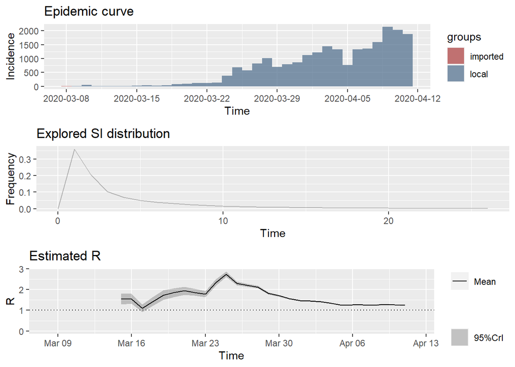

```r
plot_Ri(ma_res)
```

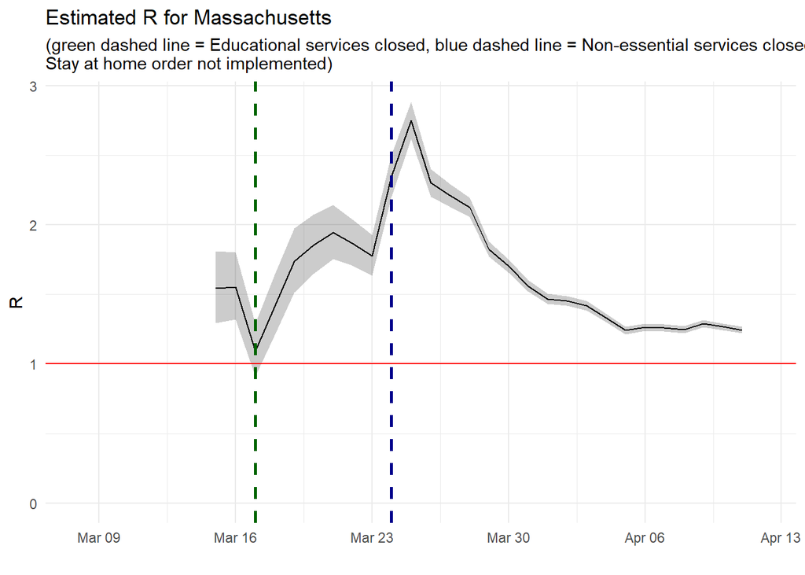

```r
plot(ma_res, "R") +
  #scale_y_continuous(trans = "log2") +
  geom_hline(yintercept = 1, lty = "solid", color = "red") +
  geom_vline(xintercept = ymd('2020-03-17'), lty = 'dashed', color = 'darkgreen', size = 1) +
  geom_vline(xintercept = ymd('2020-03-24'), lty = 'dashed', color = 'darkblue', size = 1) +
  labs(x = "", title = "Estimated R for Massachusetts",
       subtitle = "(green dashed line = Educational services closed, blue dashed line = Non-essential services closed, \nStay at home order not implemented)") +
  theme_minimal() +
  theme(legend.position = 'none')
```